# Edge to Edge

Flows of Refugee Population in Afghanistan

Doris Qingyi Duanmu and Yoji Toriumi

2022-05-05

# Introduction

In this project, we tried to delve into the situation of Afghan refugees. First, we identified migration patterns from and to Afghanistan using migration data provided by UNHCR. Then, we thought about how difficult it is to flee from Afghanistan since the number of refugees is expected to increase. Lastly, we developed a board game that you can actually experience the journey of refugees from Afghanistan to neighboring countries.

Source: [BBC](https://www.bbc.com/news/world-asia-58283177)

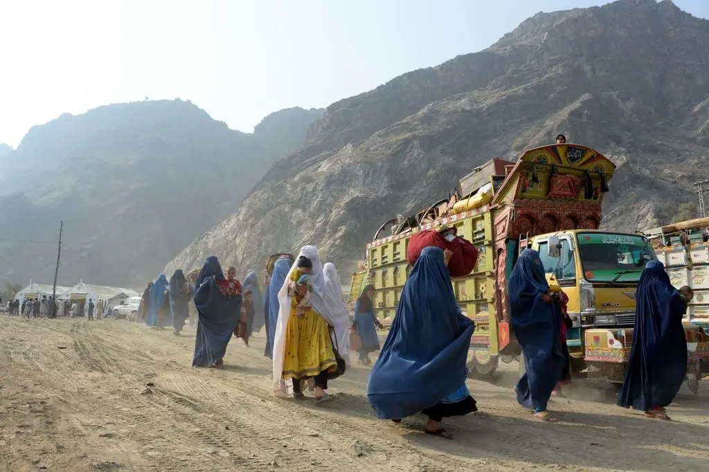

Afghan refugees

Image source: [New York Times](https://www.nytimes.com/2016/11/05/world/asia/afghanistan-migrants.html)

# Migration Patterns from and to Afghanistan

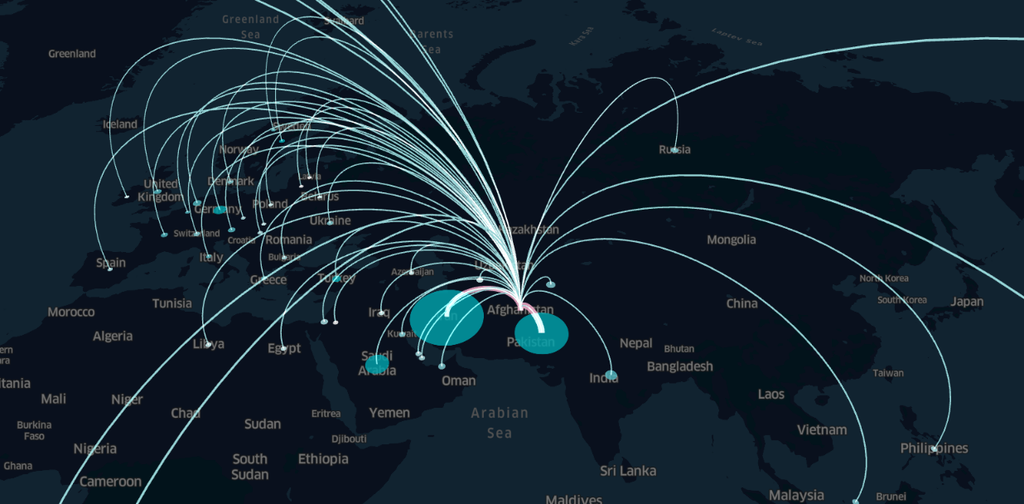

Stock and flow of Afghan migrants (click to see the interactive map)

Source: [United Nations](https://www.un.org/development/desa/pd/content/international-migrant-stock)

The migration pattern of Afghans has been heavily affected by security situations in the country. Before the Soviet Union started the invasion of Afghanistan in 1979, there were 400,000 migrants in Pakistan and 200,000 in Iran. However, it jumped up to 1.9 million by the end of the following year. After the end of the invasion in 1989, Afghan refugees returned to their country and it is estimated that more than 3.4 million Afghans arrived from 1990 to 1995.

Source: [UNHCR](https://www.unhcr.org/publications/refugeemag/3b680fbfc/refugees-magazine-issue-108-afghanistan-unending-crisis-biggest-caseload.html)

After the end of the war, the Taliban began to gain momentum in Afghanistan and controlled 90 percent of Afghanistan by the end of the 1990s. In December 2001, the International Security Assistance Force (ISAF) was established and started its operation in Afghanistan. When we look at Pakistan, a lot of refugees returned to Afghanistan from 2002 to 2007 since ISAF seized Afghanistan and the security was expected to settle, and UNHCR also implemented repatriation programs. However, because of an increased conflict in Afghanistan, the number of refugees again increased in Pakistan after 2007.

Source: [The New Humanitarian](https://www.thenewhumanitarian.org/news/2012/02/27/timeline-afghan-displacements-pakistan)

On the other hand, the number of refugees in Iran has been increasing since 2000 and it is estimated that Iran become the host country for the highest number of Afghan migrants. Some reasons could be the migrants have been getting benefited from education, medical and employment opportunities in Iran. In addition, women are allowed to go to school and work in Iran.

Source: [UNHCR](https://www.unhcr.org/publications/refugeemag/3b680fbfc/refugees-magazine-issue-108-afghanistan-unending-crisis-biggest-caseload.html)

Iran and Pakistan are the two major countries that accept refugees from Afghanistan. When we look at other countries, we notice that the number of refugees is heavily affected by refugee acceptance policies in these countries. For example, Germany adopted an open-door policy in 2015 and there had been a huge influx of refugees from all over the world to the country. Afghan refugees in Germany also tripled between 2015 and 2020.

Source: [BBC](https://www.bbc.com/news/world-europe-34402001)

# How do Afghan Refugees Flee Neighboring Countries?

[figure not shown]

Crossing points and refugee camps in Pakistan and Iran

Source: [UNHCR](https://data2.unhcr.org/en/geoservices/), [Esri](https://esri.maps.arcgis.com/home/item.html?id=1453082255024699af55c960bc3dc1fe)

There are several formal and informal crossing points between Afghanistan and Pakistan, and Afghanistan and Iran. To arrive at refugee camps over the borders is not an easy task. The northeastern part of Afghanistan is a mountainous area, and it gets cold in winter. On the other hand, the southern part of Afghanistan is bare land and refugees have to pass hundreds of miles of desert.

Source: skynews

Even if refugees arrive at any of the crossing points, they do not always get through the border safely since neighboring countries may change their operations and construct fences at crossing points. Refugees try to illegally cross the border using informal crossing points, but these attempts are always fraught with danger and they have to risk their lives to cross.

Source: [ANI](https://www.aninews.in/news/world/asia/nearly-100-afghan-refugees-shot-dead-by-iranian-security-forces-during-past-6-months-local-officials20220208222921/)

[figure not shown]

Balkan route

Source: [BBC](https://www.bbc.com/news/world-europe-34568499), [reliefweb](https://reliefweb.int/map/world/western-balkans-route-refugeemigration-crisis-echo-daily-map-03092015)

For some of the refugees, arriving in the neighboring countries is not the end of their journey. They aim to arrive in European countries using the Balkan route, where they can find job opportunities and receive a better education. In that case, they have to commit more time and money and risk themselves since borders are more strictly protected and illegal crossing lead to unfortunate consequences.

Source: [The Guardian](https://www.theguardian.com/world/2015/oct/16/afghan-refugee-shot-dead-police-turkey-enter-bulgaria), [Aljazeera](https://www.aljazeera.com/news/2021/10/29/greece-rescues-cargo-ship-carrying-400-migrants-and-refugees)

# Let’s Experience Their Journey!

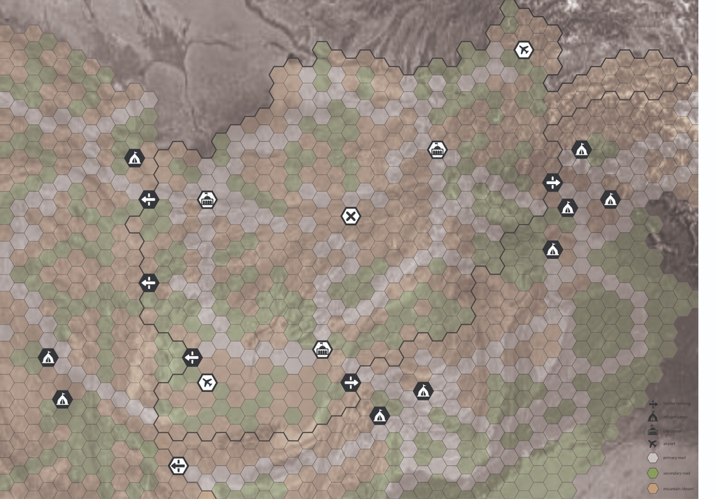

We have developed a board game to experiment journeys of refugees. You can download materials necessary for playing the game from the following link.

- [Rule Book](https://github.com/yoji-toriumi/migration_pattern/files/8635845/rulebook.pdf)
- [Game Board](https://github.com/yoji-toriumi/migration_pattern/files/8635848/gameboard.pdf)
- [Counting Board](https://github.com/yoji-toriumi/migration_pattern/files/8635847/COUNTING.BOARD.pdf)
- [Identity Card](https://github.com/yoji-toriumi/migration_pattern/files/8635849/Identity.Card-Scenario.pdf)
- [Chance Card](https://github.com/yoji-toriumi/migration_pattern/files/8635851/Chance.Card.pdf)
- [Commodity Card](https://github.com/yoji-toriumi/migration_pattern/files/8635846/Commodity.Card-1.pdf)
- [Resource Card](https://github.com/yoji-toriumi/migration_pattern/files/8635850/Resource.Card.pdf)